# topic #6, polysemous verbs with light and concrete senses.

2024-02-01 07:07:48

## term paper draft

> “If onomasiological frequency measurements do indeed correlate with elicitation tests, potential impact would be immense. Researchers would be able to examine onomasiological frequencies in spoken corpora rather than performing elicitation tests. That possibility would facilitate cognitive research into languages and varieties around the world, without the necessity of in situ psycholinguistic testing, and would also encourage the creation of more spoken corpora.” ([Mehl (2021) p.23](https://doi.org/10.1515/cllt-2017-0039))

## method

### following corpus was used to determine frequencies:

Q.1: Santa Barbara corpus of spoken American English, ([UCSB et al. (2005)](https://www.linguistics.ucsb.edu/research/santa-barbara-corpus))

the corpus data was downloaded from: https://www.linguistics.ucsb.edu/sites/secure.lsit.ucsb.edu.ling.d7/files/sitefiles/research/SBC/SBCorpus.zip

### exploring scripts:

- 14015.concrete-abstract_HA.R: creates corpus of downloaded .zip
- sbc-postag.R: postags the corpus
- get-freq-df.R: first evaluation
- collexemes-01.R: 2nd evaluation script

## corpus sample

|  | scb | id | text | lfd | light | alt |
| --- | --- | --- | --- | --- | --- | --- |
| 2974 | 3 | 242 | % I wanted it to be home made Q . | 2974 | 0 | make |
| 65343 | 57 | 123 | … It’s gonna get messed up. | 65343 | NA | a-other |
| 9465 | 8 | 567 | and then I didn’t and I .. kept making like, | 9465 | 1 | make |
| 67928 | 59 | 714 | And he’s really good at making out .. the budget. | 67928 | 1 | make |
| 35078 | 30 | 612 | … God is continually .. building character. | 35078 | 0 | build |
| 61913 | 53 | 604 | and make the payroll, | 61913 | 1 | make |
| 28500 | 24 | 25 | .. Yeah. | 28500 | NA | a-other |

## distribution analysis

cf. (Mehl 2021, 11–14)

|  | ICE.written | ICE.spoken | SBC.spoken |
| --- | --- | --- | --- |
| concrete | 68 | 96 | 89 |
| light | 321 | 353 | 381 |

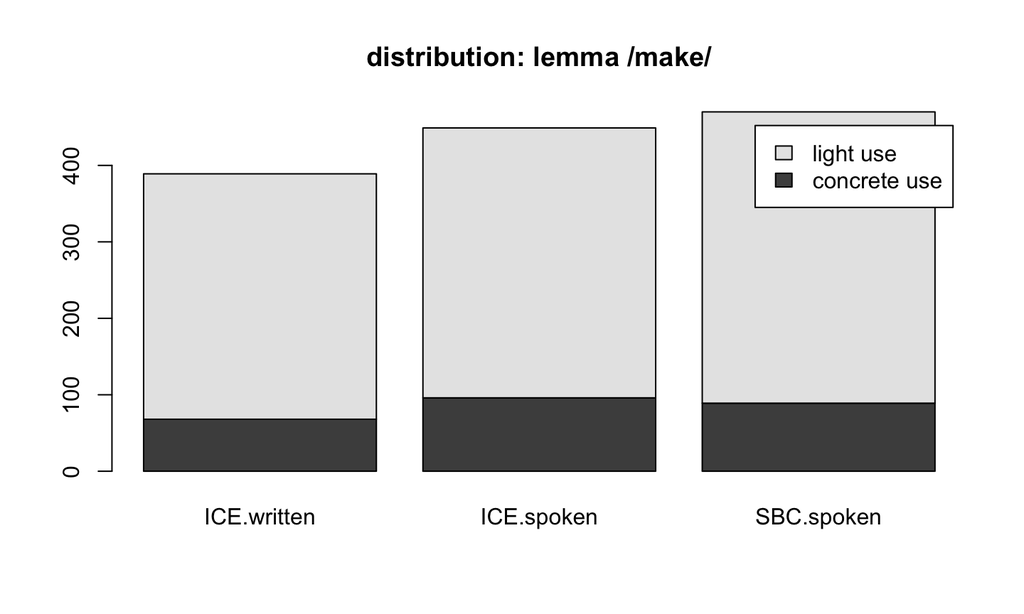

distribution of lemma /make/ over corpora. ICE data from study.

## semantic alternatives to make

- includes alternatives to /make/ that Mehl defined in his study
- all occurences are counted
  - Mehl contrasted only these alternate occurences which:

> “are defined as those verbs that occur in the corpus with the same concrete direct objects as make, (take, and give,) and with a roughly equivalent meaning.” (cf. Mehl (2021) p.13)

semantic alternatives

| Var1 | Freq |
| --- | --- |
| build | 101 |
| construct | 1 |
| create | 23 |
| generate | 4 |
| make | 89 |
| produce | 5 |

semantic alternatives

| Var1 | Freq |
| --- | --- |
| build | 101 |
| construct | 1 |
| create | 23 |
| generate | 4 |
| make | 89 |
| produce | 5 |

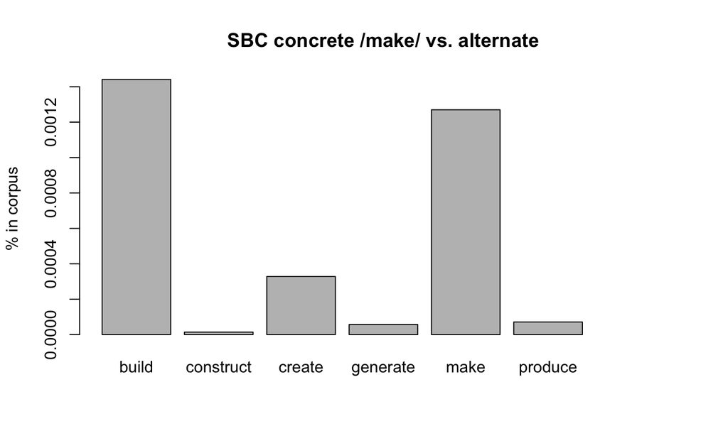

proportion of semantic alternatives to concrete /make/ in SBC

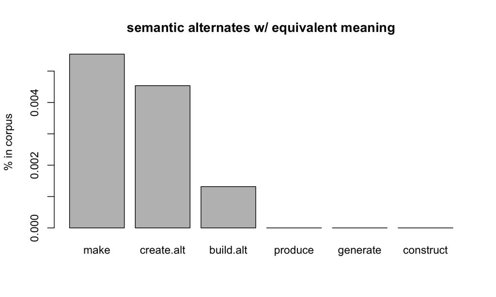

proportion of semantic alternatives, only equivalent meaning of alternates

|  | SLOT1 | SLOT2 | fS1 | fS2 | OBS | EXP | ASSOC | COLL.STR.LOGL | SIGNIF |
| --- | --- | --- | --- | --- | --- | --- | --- | --- | --- |
| 137 | finish | afghan | 13 | 2 | 2 | 0 | attr | 28.51461 | ***** |
| 654 | Filled | cookie | 1 | 6 | 1 | 0 | attr | 15.81813 | **** |
| 924 | create | Adam | 13 | 1 | 1 | 0 | attr | 14.17394 | *** |
| 928 | create | rift | 13 | 1 | 1 | 0 | attr | 14.17394 | *** |
| 930 | record | Simpsons | 13 | 1 | 1 | 0 | attr | 14.17394 | *** |
| 1337 | shovel | food | 1 | 34 | 1 | 0 | attr | 12.20185 | *** |
| 1338 | Unsweeten | food | 1 | 34 | 1 | 0 | attr | 12.20185 | *** |
| 1476 | filling | stuff | 1 | 46 | 1 | 0 | attr | 11.58948 | *** |
| 1518 | create | cause | 13 | 2 | 1 | 0 | attr | 11.40296 | *** |
| 1519 | create | committee | 13 | 2 | 1 | 0 | attr | 11.40296 | *** |
| 1520 | create | condition | 13 | 2 | 1 | 0 | attr | 11.40296 | *** |
| 1784 | bake | bread | 5 | 7 | 1 | 0 | attr | 10.48243 | ** |
| 1862 | roll | tamale | 8 | 5 | 1 | 0 | attr | 10.19627 | ** |
| 2626 | record | trip | 13 | 8 | 1 | 0 | attr | 8.15687 | ** |
| 3307 | record | game | 13 | 16 | 1 | 0 | attr | 6.71671 | ** |

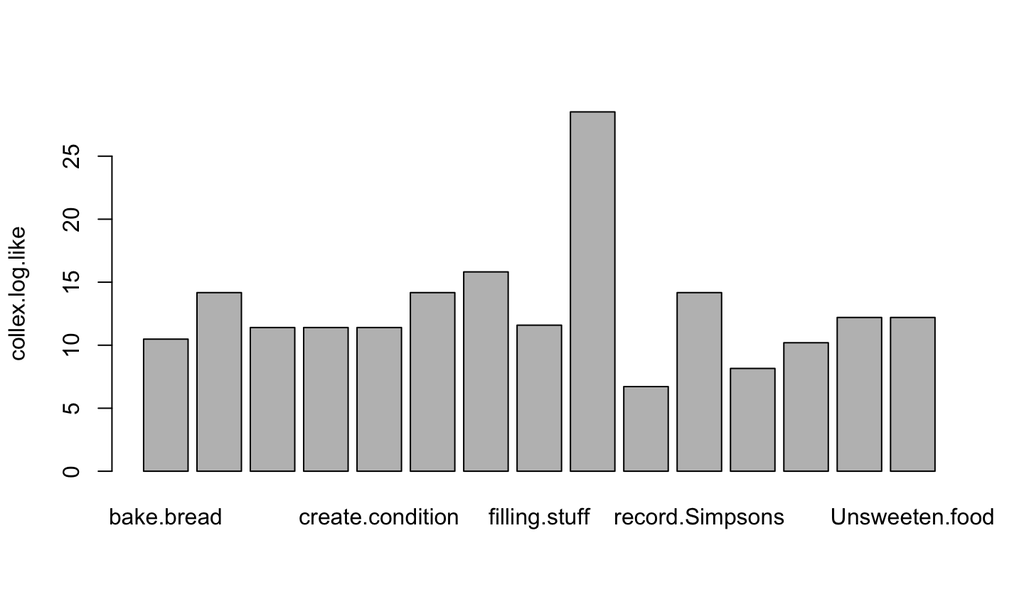

semasiological log.like of near synonymes to make

## 2nd approach collexeme evaluation

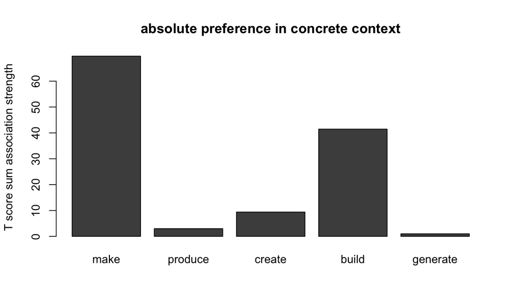

semasiological: sum T-score of near synonymes to make

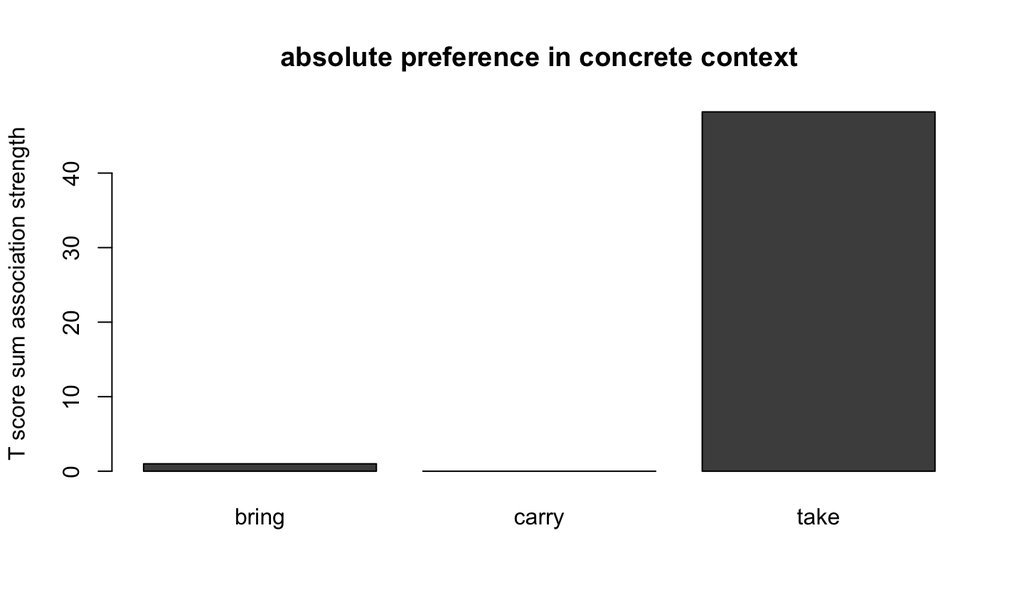

semasiological: sum T-score of near synonymes to take

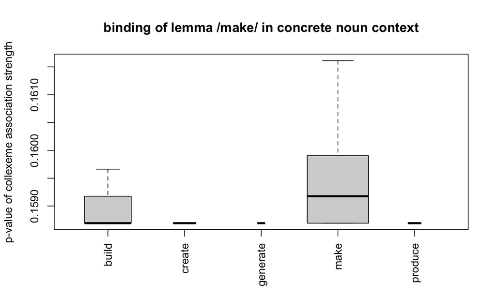

semasiological: p of near synonymes to make

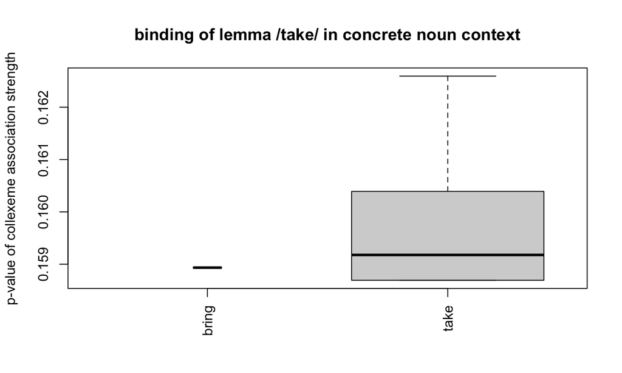

semasiological: p of near synonymes to take

## B: references

Mehl, Seth. 2021. “What We Talk about When We Talk about Corpus Frequency: The Example of Polysemous Verbs with Light and Concrete Senses.” *Corpus Linguistics and Linguistic Theory* 17 (1): 223–47. https://doi.org/10.1515/cllt-2017-0039.

UCSB, John W. DuBois, L. Chafe Wallace, Charles Meyer, Sandra A. Thompson, Robert Englebretson, and Nii Martey. 2005. “Santa Barbara Corpus of Spoken American English Department of Linguistics - UC Santa Barbara.” *SBC*. https://www.linguistics.ucsb.edu/research/santa-barbara-corpus.